# Visualización de Geodésicas usando EinsteinPy

$\hspace{1.5cm}$

[figure not shown]

$\hspace{2cm}$

[figure not shown]

$\hspace{2cm}$

[figure not shown]

```python
1+1
```

```
2
```

## Geodésicas en torno a un agujero negro de Schwarzschild

- Obs: desde la forma de la métrica de Schwarzschild se sabe que el movimiento está restringido a un plano, luego, se trabajará con gráficas en 2 dimensiones para este tipo de escenarios

### Parámetros por defecto: Geodesic()

**steps** (int) – Number of integration steps Defaults to **50**

**delta** (float) – Initial integration step-size Defaults to **0.5**

**rtol** (float) – Relative Tolerance Defaults to **1e-2**

**atol** (float) – Absolute Tolerance Defaults to **1e-2**

**order** (int) – Integration Order Defaults to **2**

**omega** (float) – Coupling between Hamiltonian Flows Smaller values imply smaller integration error, but too small values can make the equation of motion non-integrable. For non-capture trajectories, omega = 1.0 is recommended. For trajectories, that either lead to a capture or a grazing geodesic, a decreased value of 0.01 or less is recommended. Defaults to **1.0**

These parameters are for controlling numerical integration when solving geodesic equations, typically in General Relativity simulations (e.g., with einsteinpy). They influence precision, stability, and performance of how the path of a particle or photon is computed through curved spacetime

```python
import seaborn as sns
import numpy as np
import matplotlib.pyplot as plt
from einsteinpy.geodesic import Timelike, Nulllike
#from einsteinpy.plotting.geodesic import StaticGeodesicPlotter
#from einsteinpy.symbolic import Schwarzschild
```

```python
'''   Functions [Move to a separate file]   '''
# Definir función para graficar coordenadas
def plotgeod_q(q, leap, max_ind, name, save=False, mark=0):

    # Definir coordenadas
    t, x, y = q[0][:max_ind:leap], q[1][:max_ind:leap], q[2][:max_ind:leap]

    plt.figure(figsize=(14,5))
    plt.scatter(x, y, c=range(len(t)), cmap='coolwarm', s=6, alpha=.9)
    plt.plot(0, 0, "ko", label="BH")

    # Event horizon
    rBH = 2.
    xBH = np.linspace(-rBH,rBH,40)
    yBH = np.sqrt(rBH**2-xBH**2)
    plt.plot(xBH,yBH,'k--',xBH,-yBH, 'k--')

    if mark:
        plt.plot(x[-mark:], y[-mark:], 'k*', markersize=13)
    plt.colorbar(label="~Time")
    plt.xlabel("x", fontsize=12.5)
    plt.ylabel("y", fontsize=12.5)
    plt.title(name, fontsize=12.5)
    plt.legend(fontsize=12.5)
    if save:
        plt.savefig(name+'.png', dpi=400)
    plt.show()

# Plot momentum
def plotgeod_p(q, p, leap, max_ind, name, save=False, mark=0):               # fix to have max_ind=-1 by default

    # Definir coordenadas [esféricas]
    t, E = q[0][:max_ind:leap], p[0][:max_ind:leap]
    p_r, p_theta, p_phi = p[1][:max_ind:leap], p[2][:max_ind:leap], p[3][:max_ind:leap]

    fig, axs = plt.subplots(figsize=(14,5),nrows=1, ncols=2)
    fs=15

    # Energy
    axs[0].plot(t, E, label=f'E(0)={round(E[0],2)}')
    axs[0].set_title('E(t)', fontsize=fs)
    axs[0].set_xlabel('~Time')
    axs[0].set_ylabel('Energy')
    axs[0].legend(fontsize=fs, loc='upper left')

    # 3-momentum:
    axs[1].plot(t,p_r, label=fr'$P_r(0)=${round(p_r[0], 2)}')
    axs[1].plot(t,p_theta, label=fr'$P_\theta(0)=${round(p_theta[0],2)}')
    axs[1].plot(t,p_phi, label=fr'$P_\phi(0)=${round(p_phi[0],2)}')
    axs[1].set_title('3-momentum', fontsize=fs)
    axs[1].set_xlabel('~Time')
    axs[1].set_ylabel('3-momentum')
    axs[1].legend(fontsize=fs, loc='lower left')

    if mark:
        axs[0].plot(t[-mark:], E[-mark:], 'k*', markersize=13)          #Not quite happy with this
    if save:
        plt.savefig(name+'.png', dpi=400)

    plt.tight_layout()
    plt.show()

###   Plot n particles    ###
# Same idea as plotgeod_q, but for more particles
# Note that the steps and delta ought to be the same for all particles
# Preferably, same parameters (atol, rtol, omega, order)
# Warning: for now it only supports up to 3 particles and a black hole Mass = 1

def plotgeod_q2(q_list, name, max_ind, a, leap=[1,1,1], save=False, ani=False, lims=[0]):         #, mark=0):

    # Definir coordenadas
    t_list = [q_list[i][0][:max_ind[i]:leap[i]] for i in range(len(q_list))]
    x_list = [q_list[i][1][:max_ind[i]:leap[i]] for i in range(len(q_list))]
    y_list = [q_list[i][2][:max_ind[i]:leap[i]] for i in range(len(q_list))]
    #cmap_list = ['coolwarm', 'viridis', 'jet']
    color_list = ['red', 'green', 'blue']
    marker_list = ['1', 'd', '^']

    plt.figure(figsize=(14,5))
    plt.plot(0, 0, "ko", label="BH")                                # point BH
    for i in range(len(q_list)):
        # Geodesics
        plt.scatter(x_list[i], y_list[i], c=color_list[i], marker=marker_list[i],s=12, alpha=.7, label=f'Particle {1+i}')
        #plt.colorbar(label=f"~Time | {i}")     #too messy with 3 colorbars; for absorbed geodesics we can do withouth

    # Event horizon [Update this to support ergosphere and other Kerr BH features]
    ## Schild BH (1 event horizon)
    if name[0]=='S':
        rS = 2.
        xS = np.linspace(-rS,rS,40)
        yS = np.sqrt(rS**2-xS**2)
        plt.plot(xS,yS,'k--',xS,-yS, 'k--')

    ## Kerr BH (2 event horizons + 1 ergosphere)   [Obs: not spherical (Euclidean sense), but S^2 topology]
    elif name[0]=='K':
        r_plus = 1 + np.sqrt(1-a**2)
        r_minus= 1 - np.sqrt(1-a**2)
        xK_p = np.linspace(-r_plus, r_plus, 30)
        yK_p = np.sqrt(r_plus**2 - xK_p**2)
        xK_m = np.linspace(-r_minus, r_minus, 30)
        yK_m = np.sqrt(r_minus**2 - xK_m**2)
        plt.plot(xK_p,yK_p,'k--', label='OH')                 # outer horizon
        plt.plot(xK_p,-yK_p, 'k--')
        plt.plot(xK_m,yK_m,'k--', alpha=.7, label='IH')     # inner horizon
        plt.plot(xK_m,-yK_m, 'k--', alpha=.7,)
        print(r_plus, r_minus)

        # ergosphere [at the Equator, equal to Schild radius; independent of a]
        rERG = 2.
        xERG = np.linspace(-rERG,rERG,30)
        yERG = np.sqrt(rERG**2-xERG**2)
        plt.plot(xERG,yERG,'g--', label='ERG')      #ergosphere
        plt.plot(xERG,-yERG, 'g--',)

    #if mark:
    #    plt.plot(x[-mark:], y[-mark:], 'k*', markersize=13)
    #plt.colorbar(label="~Time")

    if lims[0]!=0:
        plt.xlim(lims[0], lims[1])
        plt.ylim(lims[2], lims[3])

    plt.xlabel("x [GM/c^2]", fontsize=12.5)
    plt.ylabel("y [GM/c^2]", fontsize=12.5)
    plt.title(name, fontsize=12.5)
    plt.legend(fontsize=12.5)
    if save==True:
        plt.savefig(name+'.png', dpi=400)
    if ani==False:
        plt.show()
```

```python
# set plot theme
sns.set_theme(context='notebook', style='darkgrid', palette='colorblind')
```

### Prototipo de simulación

1. Definir condiciones iniciales y parámetros de Geodesic()
2. Calcular geodésica (Timelike or Nulllike)
   - Tomar nota de *Warnings*
3. Obtener trayectoria: 4-posición y 4-momentum
4. Graficar evolución temporal de la posición (plano ecuatorial)
   - Investigar errores
   - Graficar 4-momentum
5. Concluciones
6. Exportar resultados o volver a al paso **1.**

Ecuación Geodésica

$$ \frac{d^2x^{\mu}}{d\lambda^2}+\Gamma_{\nu\sigma}^{\mu}\frac{dx^\nu}{d\lambda}\frac{dx^\sigma}{d\lambda}$$

Los pasos de la integración se realizan sobre el parámetro afín $\lambda$

La primera componente de la 4-posición $x^0(λ) = t(λ)$ es parte de la solución de esta ecuación. Luego, qué tan rápido cambia $t$ respecto a $\lambda$ dependerá del momentum inicial y la geometría del espacio en ese punto.

```python
# Condiciones iniciales
position = [56., np.pi / 2, 0.]            # r, theta, phi (x=56, y=z=0)
momentum = [0., 0., 3.83405]               # momento inicial solo en phi
a = 0.                                     # Spin = 0 for a Schwarzschild black hole
steps = 5500                               # Number of steps to be taken by the solver
delta = 1                                  # default is set to 0.5
```

```python
geod = Timelike(                    # m>0
    metric="Schwarzschild",
    metric_params=(a,),
    position=position,
    momentum=momentum,
    steps=steps,
    delta=delta,
    suppress_warnings=True,
    return_cartesian=True        # Obs: Momenta are dimensionless quantities, and are returned in Spherical Polar Coordinates.
)
#print(geod)
```

```python
# 4-posición y 4-momentum
q = geod.trajectory[1].T[:4]         #[GM/c^2]
p = geod.trajectory[1].T[-4:]
```

```python
q[1]
```

```
array([5.59998939e+01, 5.59993694e+01, 5.59985728e+01, ...,
       2.14083123e+05, 1.94292710e+05, 1.85140955e+05], shape=(5500,))
```

```python
q[2]
```

```
array([ 6.84651348e-02,  1.36929665e-01,  2.05393464e-01, ...,
       -4.75899271e+04, -1.01777092e+05, -1.17696597e+05], shape=(5500,))
```

```python
p[2]
```

```
array([2.87025740e-19, 5.74054660e-19, 8.61087728e-19, ...,
       1.07740099e-15, 1.32112061e-15, 1.42160205e-15], shape=(5500,))
```

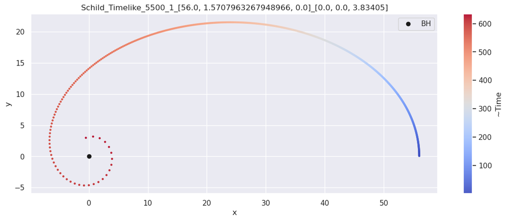

```python
# Definir cuadriposición y cuadrimomentum

q = geod.trajectory[1].T[:4]                  # 4-position (cartesian) [Units of GM/c^2]
p = geod.trajectory[1].T[-4:]                 # 4 momentum (spherical) [dimensionless]

leap = 1
max_ind = 584

# name output
metric = 'Schild'       # Kerr
kind = 'Timelike'       # Nulllike
name = metric +'_'+ kind +'_'+ str(steps) +'_'+ str(delta) +'_'+ str(position) +'_'+ str(momentum)

plotgeod_q(q, leap, max_ind, name, save=False)
```

**Hasta aquí todo parece correcto**: el momento inicial de la partícula no es el suficiente para orbitar de manera estable al agujero negro y en poco tiempo terminará cayendo...

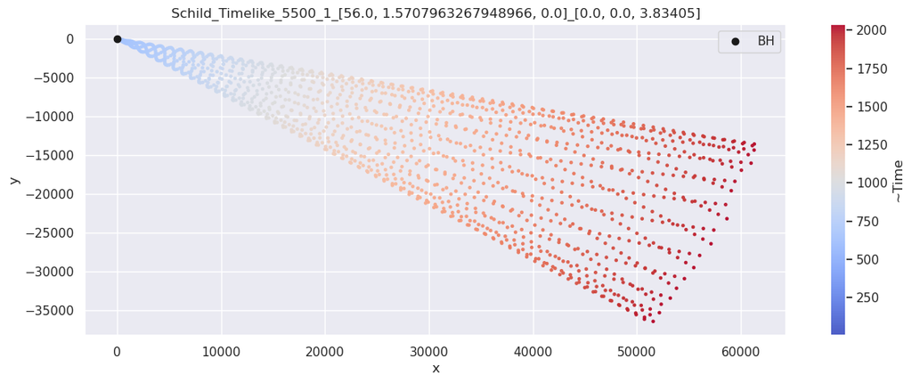

```python
plotgeod_q(q, leap, max_ind=2000 ,name=name)
```

Algo falló, ahora acerquémonos...

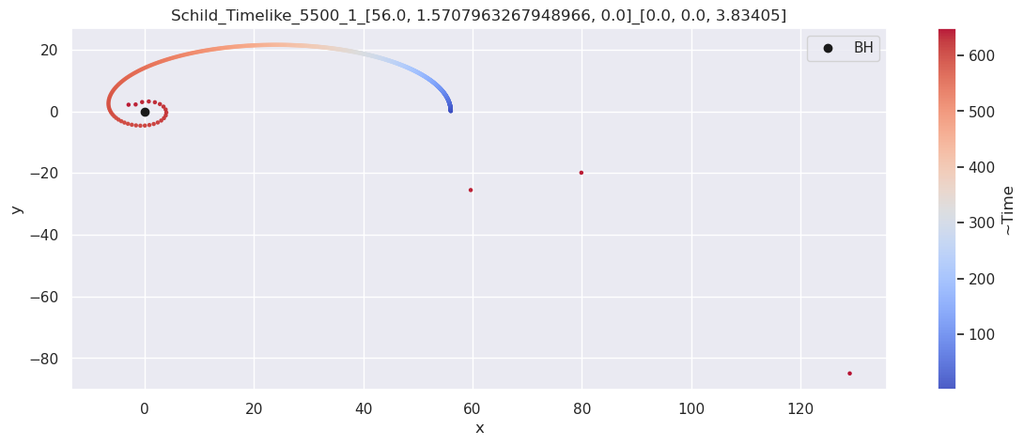

```python
plotgeod_q(q, leap, max_ind=589 ,name=name)
```

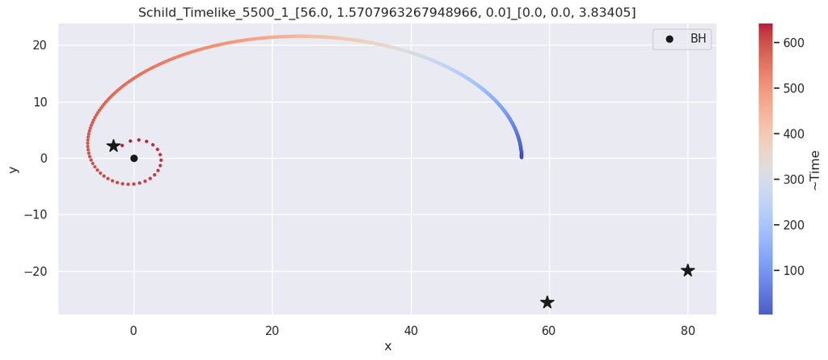

```python
plotgeod_q(q, leap, max_ind=588 ,name=name, mark=3)
```

Obs: notar que la separación entre los puntos fue incrementando a medida que la partícula se acercaba al BH, esto sugiere que la simulación requería de un step más pequeño para que la simulación mantuviera la estabilidad

Veamos ahora el comportamiento del cuadrimomento

```python
# How to get initial conditions
geod.position
geod.momentum
```

[output not shown]

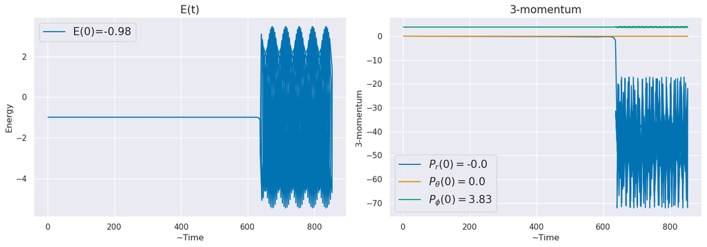

```python
plotgeod_p(q, p, leap, max_ind=800, name=name)
```

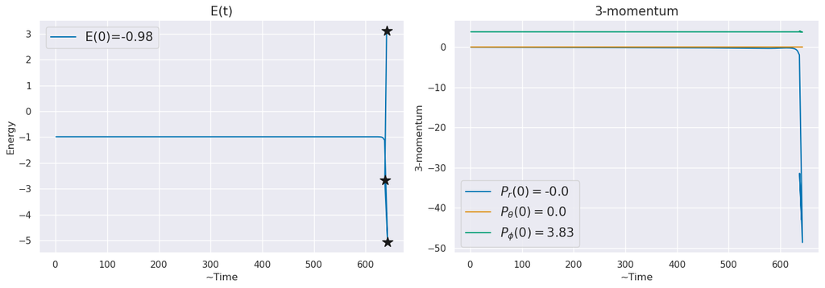

```python
plotgeod_p(q, p, leap, max_ind=588, name=name, mark=3)
```

```python
# Usando una las funciones integradas en einsteinpy
from einsteinpy.plotting import GeodesicPlotter

gpl = GeodesicPlotter()

gpl.clear()
gpl.parametric_plot(geod, colors=("red", "green", "blue"))
gpl.show()
```

### Ajustar omega y delta

#### 1st Try

Siguiendo las recomendaciones de la documentación, para trayectorias donde la partícula es absorbida,

es recomendable utilizar un valor de `omega`$\leq0.01$. Adicionalmente, se utiliza `delta`=0.5

```python
import seaborn as sns
import numpy as np
import matplotlib.pyplot as plt
from einsteinpy.geodesic import Timelike
from einsteinpy.plotting.geodesic import StaticGeodesicPlotter
from einsteinpy.symbolic import Schwarzschild
```

```python
# Condiciones iniciales
position = [56., np.pi / 2, 0.]            # r, theta, phi (x=56, y=z=0)
momentum = [0., 0., 3.83405]               # momento inicial solo en phi
a = 0.                                     # Spin = 0 for a Schwarzschild black hole
steps = 1200                               # Number of steps to be taken by the solver
delta = 0.5
omega = 0.002
```

```python
geod = Timelike(                    # m>0
    metric="Schwarzschild",
    metric_params=(a,),
    position=position,
    momentum=momentum,
    steps=steps,
    delta=delta,
    omega=omega,
    suppress_warnings=False,          #True,
    return_cartesian=True        # Obs: Momenta are dimensionless quantities, and are returned in Spherical Polar Coordinates.
)
#print(geod)
```

```python
geod.trajectory[1].T[0]-geod.trajectory[0]              # Is this numeric error or time dilation...
```

```
array([ 5.10367056e-01,  2.07341326e-02, -4.68898751e-01, ...,
        8.30438125e+08,  8.57063129e+08,  8.84541768e+08], shape=(1200,))
```

```python
geod.trajectory[0]              # = range(steps)
```

```
array([   0,    1,    2, ..., 1197, 1198, 1199], shape=(1200,))
```

```python
geod.trajectory[1].T[0]                                 # Not even ordered?
```

```
array([5.10367056e-01, 1.02073413e+00, 1.53110125e+00, ...,
       8.30439322e+08, 8.57064327e+08, 8.84542967e+08], shape=(1200,))
```

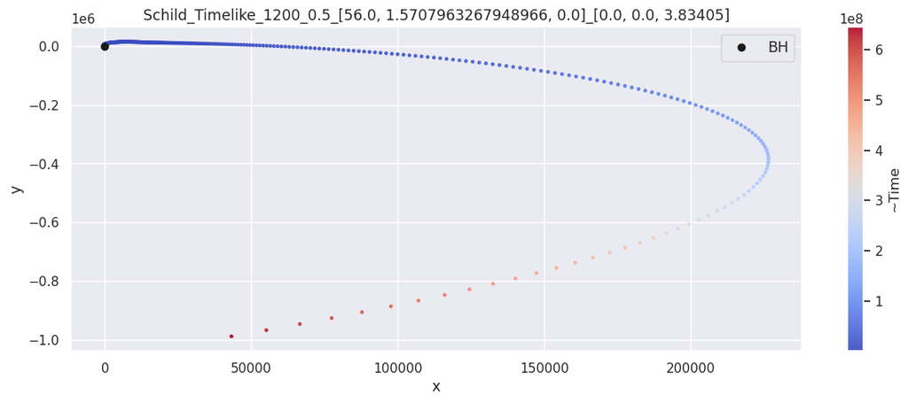

```python
# Definir 4-posición y 4-momentum

q = geod.trajectory[1].T[:4]                  # 4-position (cartesian) [Units of GM/c^2]
p = geod.trajectory[1].T[-4:]                 # 4 momentum (spherical) [dimensionless]

leap = 1
max_ind = 1190

# name output
metric = 'Schild'       # Kerr
kind = 'Timelike'       # Nulllike
name = metric +'_'+ kind +'_'+ str(steps) +'_'+ str(delta) +'_'+ str(position) +'_'+ str(momentum)

plotgeod_q(q, leap, max_ind, name, save=False)
```

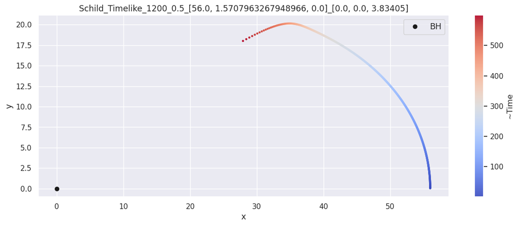

```python
plotgeod_q(q, leap, max_ind=720, name=name)
```

Esta vez los errores numéricos comenzaron incluso antes de acercarse al agujero negro

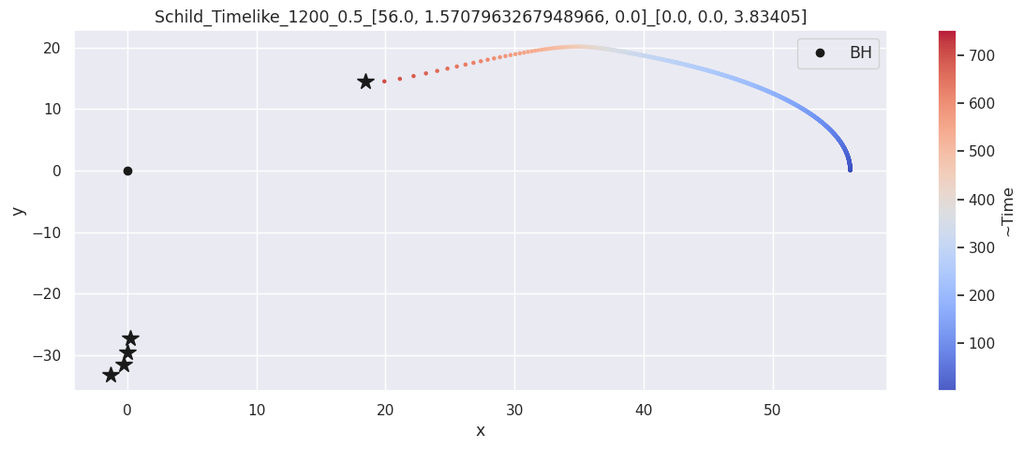

```python
plotgeod_q(q, leap, max_ind=735, name=name, mark=5)
```

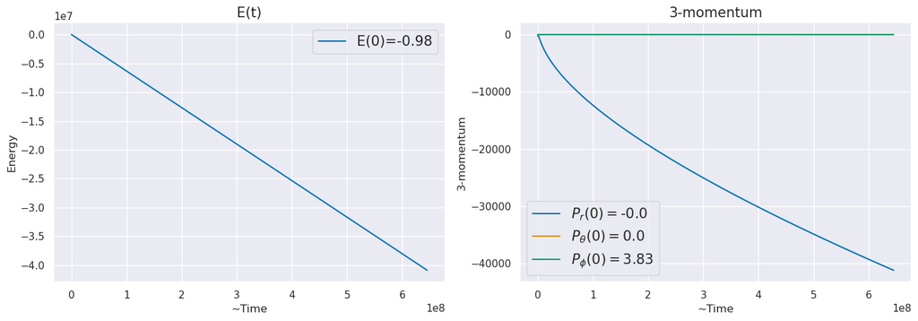

```python
plotgeod_p(q, p, leap, max_ind=1190, name=name)
```

Ahora nos acercámos a los puntos más cercanos al BH

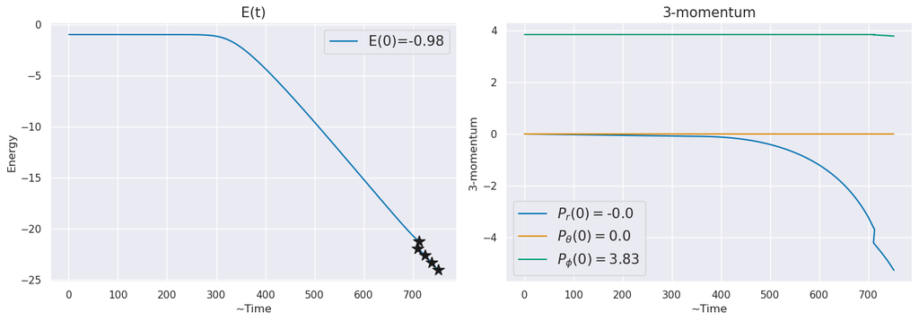

```python
plotgeod_p(q, p, leap, max_ind=735, name=name, mark=5)
```

**Obs**: Notar que los errores numéricos se intensificaron mucho antes del encuentro con el BH

#### 2nd Try

- Probar con `omega`=0.009 y reducimos a `delta`=0.2

```python
import seaborn as sns
import numpy as np
import matplotlib.pyplot as plt
from einsteinpy.geodesic import Timelike
#from einsteinpy.plotting.geodesic import StaticGeodesicPlotter
#from einsteinpy.symbolic import Schwarzschild
```

```python
# Condiciones iniciales
position = [56., np.pi / 2, 0.]            # r, theta, phi (x=56, y=z=0)
momentum = [0., 0., 3.83405]               # momento inicial solo en phi
a = 0.                                     # Spin = 0 for a Schwarzschild black hole
steps = 1200                               # Number of steps to be taken by the solver
delta = 0.2
omega = 0.009

# Calcular geodésica
geod2 = Timelike(                    # m>0
    metric="Schwarzschild",
    metric_params=(a,),
    position=position,
    momentum=momentum,
    steps=steps,
    delta=delta,
    omega=omega,
    suppress_warnings=False,          #True,
    return_cartesian=True        # Obs: Momenta are dimensionless quantities, and are returned in Spherical Polar Coordinates.
)

#print(geod)

# First warning
#Numerical error has exceeded specified tolerance at step = 655.
```

[figure not shown]

```python
# Definir 4-posición y 4-momentum

q = geod2.trajectory[1].T[:4]                  # 4-position (cartesian) [Units of GM/c^2]
p = geod2.trajectory[1].T[-4:]                 # 4 momentum (spherical) [dimensionless]

leap = 1
max_ind = 1190

# name output
metric = 'Schild'       # Kerr
kind = 'Timelike'       # Nulllike
name = metric +'_'+ kind +'_'+ str(steps) +'_'+ str(delta) +'_'+ str(position) +'_'+ str(momentum)

plotgeod_q(q, leap, max_ind, name, save=False)
```

Now zoom in...

[figure not shown]

```python
plotgeod_q(q, leap, max_ind=940, name=name, save=False)
```

Resultados similares a los obtenidos en la sección anterior, los errores comienzan a ser significativos mucho antes de acercarse al BH

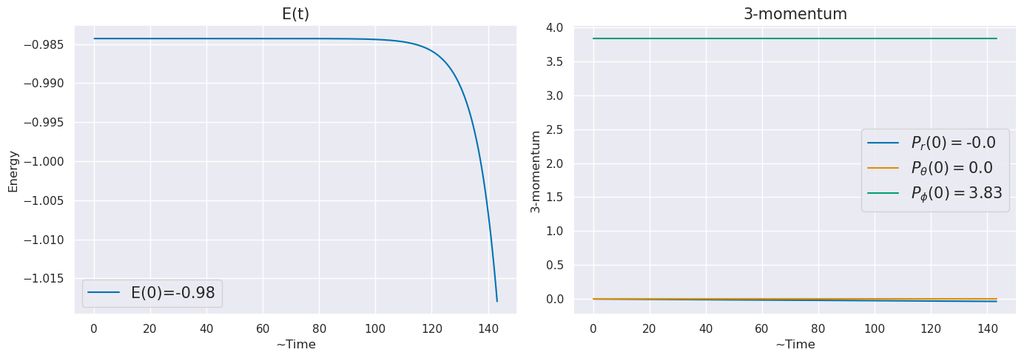

```python
plotgeod_p(q, p, leap, max_ind=700, name=name)
```

Al parecer las variaciones en el momento y en la energía no son significativas, pero se empieza a notar que el momento radial comienza a disminuir

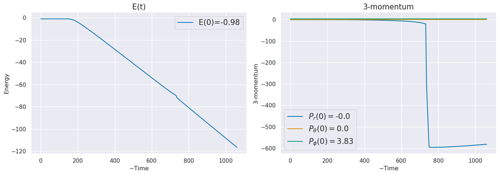

```python
plotgeod_p(q, p, leap, max_ind=1000, name=name)
```

#### 3rd Try

- Aumentar el orden del RK (2 $\to$ 4) y utilizar `delta`=1.0 y `omega`=1.0 (para resolver de buena forma la primera parte de la trayectoria)

```python
# Condiciones iniciales
position = [56., np.pi / 2, 0.]            # r, theta, phi (x=56, y=z=0)
momentum = [0., 0., 3.83405]               # momento inicial solo en phi
a = 0.                                     # Spin = 0 for a Schwarzschild black hole
steps = 1200                               # Number of steps to be taken by the solver
delta = 1.0
omega = 1.0
order = 4

# Calcular geodésica
geod3 = Timelike(                    # m>0
    metric="Schwarzschild",
    metric_params=(a,),
    position=position,
    momentum=momentum,
    steps=steps,
    delta=delta,
    omega=omega,
    order=order,
    suppress_warnings=False,          #True,
    return_cartesian=True        # Obs: Momenta are dimensionless quantities, and are returned in Spherical Polar Coordinates.
)

# First warning
# Numerical error has exceeded specified tolerance at step = 582.
```

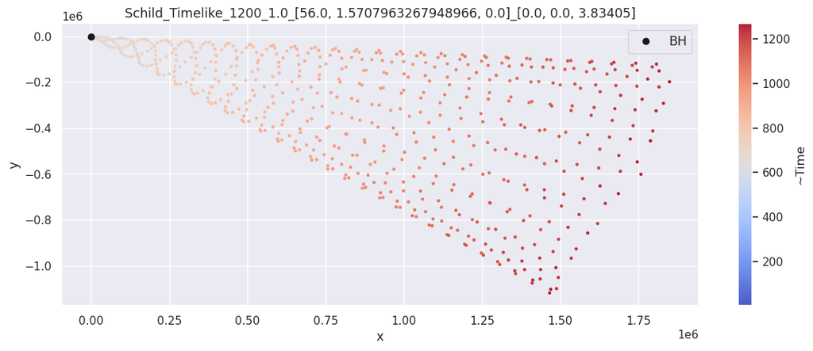

```python
# Definir 4-posición y 4-momentum

q = geod3.trajectory[1].T[:4]                  # 4-position (cartesian) [Units of GM/c^2]
p = geod3.trajectory[1].T[-4:]                 # 4 momentum (spherical) [dimensionless]

leap = 1
max_ind = 1190

# name output
metric = 'Schild'       # Kerr
kind = 'Timelike'       # Nulllike
name = metric +'_'+ kind +'_'+ str(steps) +'_'+ str(delta) +'_'+ str(position) +'_'+ str(momentum)

# Plot q
plotgeod_q(q, leap, max_ind, name, save=False)
```

Similar al resultado obtenido en la primera sección. Now zoom in...

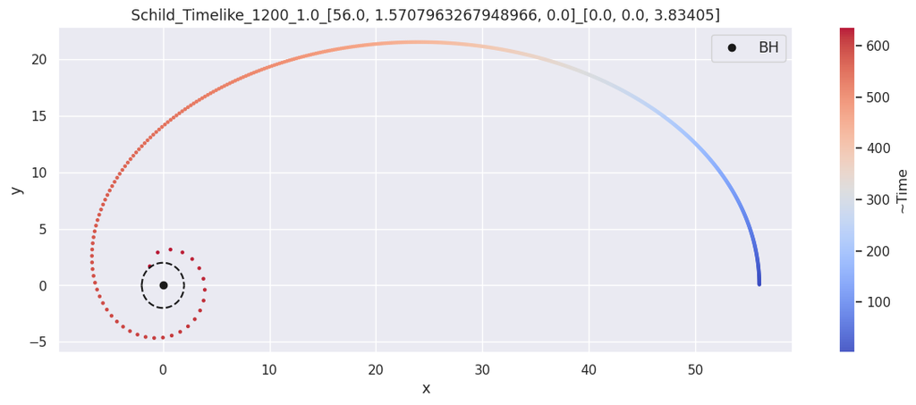

```python
plotgeod_q(q, leap, max_ind=585, name=name, save=False)         # Notar que los últimos 3 puntos ya sobrepasaron
                                                                # la tolerancia seteada
```

Esta vez sí se obtiene una simulación estable antes de llegar al BH

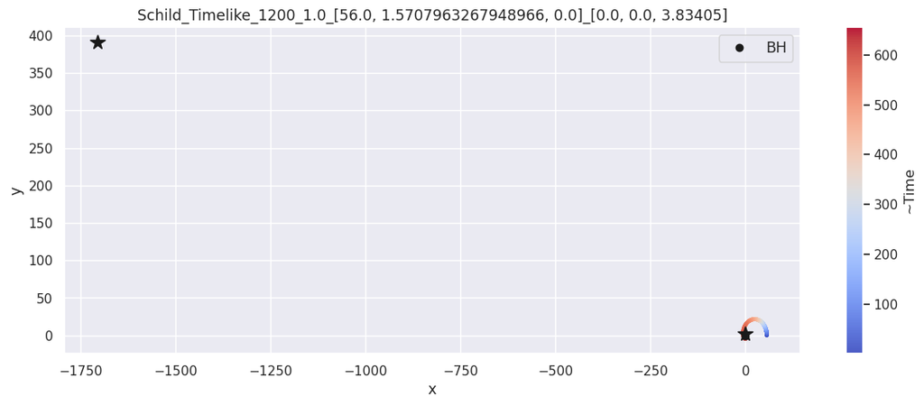

```python
plotgeod_q(q, leap, max_ind=586, name=name, save=False, mark=2)
```

Naturalmente, luego de llegar al horizonte de eventos, la simulación carece de sentido

### Clasificar geodésicas y aplicar early-stopping

- Timelike inner bound orbits (type IIa)
- Timelike outer bound orbits (type IIb)
- Timelike unbound absorbed orbits (type IIIa)
- Timelike unbound scattered orbits (type IIIb)
- Null bound orbits (type II)
- Null unbound obsorbed orbits
- Null unbound scattered orbits
- Para las orbitas absorbidas, es necesario aplicar un early-stopping justo antes de que la partícula entre al agujero negro
- En general, se necesita detener la simulación si se ha excedido la tolerancia fijada para el error

#### Null unbound Scatter orbits

```python
import seaborn as sns
import numpy as np
import matplotlib.pyplot as plt
from einsteinpy.geodesic import Timelike, Nulllike
```

##### 1st Try

- `omega`=`delta`=1 y RK2
- Momento inicial positivo en $\phi$ y negativo en $r$

```python
# Condiciones iniciales
position = [56., np.pi / 2, 0.]            # r, theta, phi (x=56, y=z=0)
momentum = [-1., 0., 3.83405]               # momento inicial solo en phi
a = 0.                                     # Spin = 0 for a Schwarzschild black hole
steps = 1500                               # Number of steps to be taken by the solver
delta = 1.
omega = 1.
order = 2

# Calcular geodésica
geod_n1 = Nulllike(                    # m=0
    metric="Schwarzschild",
    metric_params=(a,),
    position=position,
    momentum=momentum,
    steps=steps,
    delta=delta,
    omega=omega,
    order=order,
    suppress_warnings=False,          #True,
    return_cartesian=True        # Obs: Momenta are dimensionless quantities, and are returned in Spherical Polar Coordinates.
)

#print(geod)

# First warning
# Numerical error has exceeded specified tolerance a step = 58.
```

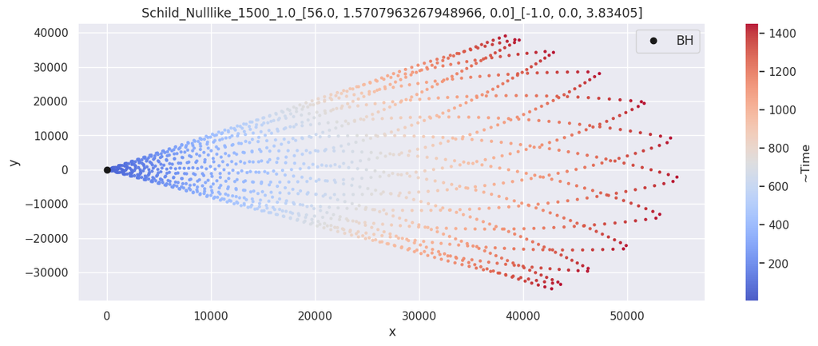

```python
# Definir 4-posición y 4-momentum

q = geod_n1.trajectory[1].T[:4]                  # 4-position (cartesian) [Units of GM/c^2]
p = geod_n1.trajectory[1].T[-4:]                 # 4 momentum (spherical) [dimensionless]

leap = 1
max_ind = steps-10

# name output
metric = 'Schild'       # or Kerr
kind = 'Nulllike'       # or Timelike
name = metric +'_'+ kind +'_'+ str(steps) +'_'+ str(delta) +'_'+ str(position) +'_'+ str(momentum)

plotgeod_q(q, leap, max_ind, name, save=False)
```

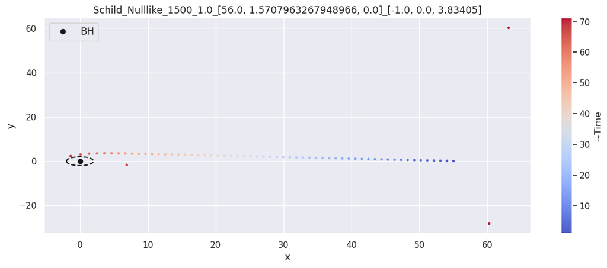

```python
plotgeod_q(q, leap, max_ind=61, name=name, save=False)
```

Se observa que los puntos están muy espaciados, lo cual sugiere que el integrador requiere de un delta más pequeño. Esto tiene sentido ya que esta partícula se está moviendo a la máxima velocidad permitida (i.e., c)

##### 2nd Try

- Disminuir el delta para que la simulación gane estabilidad. `delta`=.4
- Dado que la partícula pasa bastante cerca del BH, también se diminuye el omega. `omega`=0.5
- Adicionalmente, se disminuye la magnitud del momento en $r$ (para evitar absorción) y se utiliza RK4.

```python
# Condiciones iniciales
position = [56., np.pi / 2, 0.]            # r, theta, phi (x=56, y=z=0)
momentum = [-.7, 0., 3.83405]               # momento inicial solo en phi
a = 0.                                     # Spin = 0 for a Schwarzschild black hole
steps = 1500                               # Number of steps to be taken by the solver
delta = .4
omega = .5
order = 4

# Calcular geodésica
geod_n2 = Nulllike(                    # m=0
    metric="Schwarzschild",
    metric_params=(a,),
    position=position,
    momentum=momentum,
    steps=steps,
    delta=delta,
    omega=omega,
    order=order,
    suppress_warnings=False,          #True,
    return_cartesian=True        # Obs: Momenta are dimensionless quantities, and are returned in Spherical Polar Coordinates.
)

#print(geod)

# First warning
# Numerical error has exceeded specified tolerance a step = 91.
```

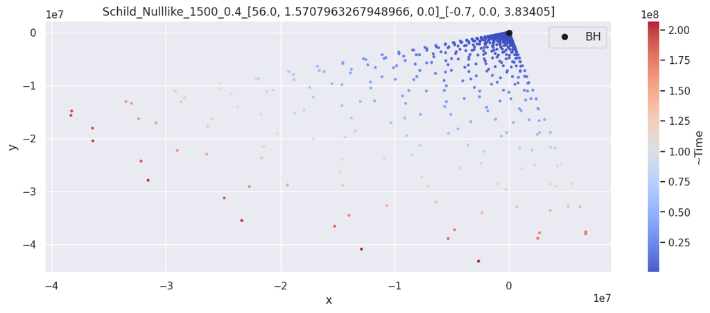

```python
# Definir 4-posición y 4-momentum

q = geod_n2.trajectory[1].T[:4]                  # 4-position (cartesian) [Units of GM/c^2]
p = geod_n2.trajectory[1].T[-4:]                 # 4 momentum (spherical) [dimensionless]

leap = 1
max_ind = steps-10

# name output
metric = 'Schild'       # or Kerr
kind = 'Nulllike'       # or Timelike
name = metric +'_'+ kind +'_'+ str(steps) +'_'+ str(delta) +'_'+ str(position) +'_'+ str(momentum)

plotgeod_q(q, leap, max_ind, name, save=False)
```

Zoom in...

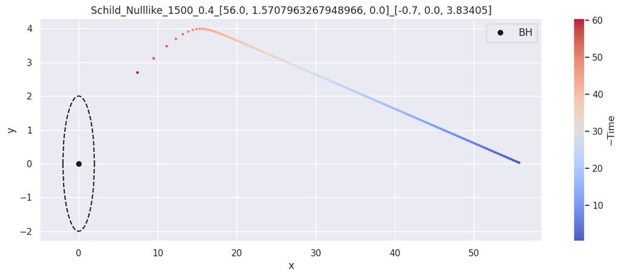

```python
plotgeod_q(q, leap, max_ind=157, name=name, save=False)
```

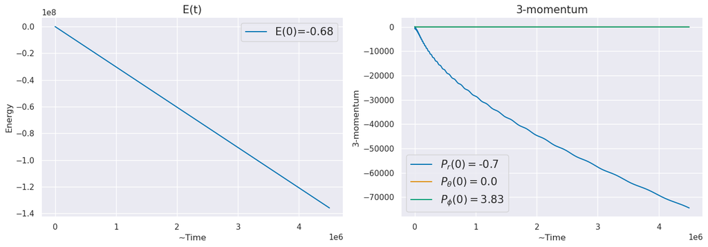

```python
plotgeod_p(q, p, leap, max_ind=1200, name=name)
```

Zoom in...

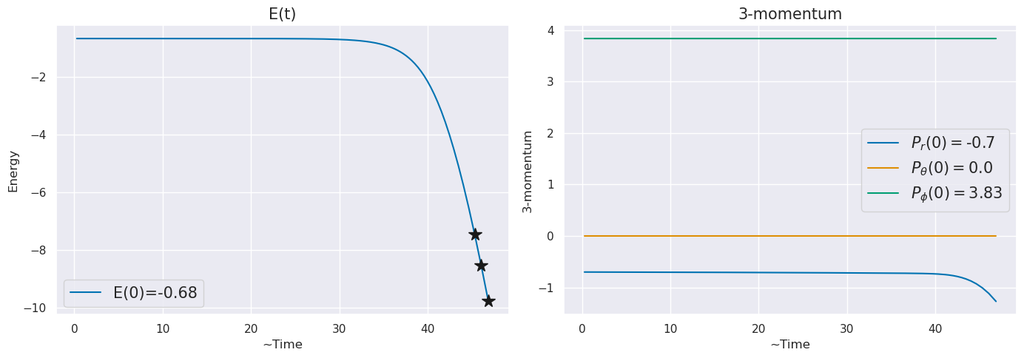

```python
plotgeod_p(q, p, leap, max_ind=150, name=name, mark=3)
```

En este caso, ya no corresponde a un defecto de las condiciones iniciales, pues se aprecia que la geodésica pasa lo suficientemente lejos del BH

##### 3rd Try

```python
# Condiciones iniciales
position = [56., np.pi / 2, 0.]            # r, theta, phi (x=56, y=z=0)
momentum = [-.4, 0., 3.83405]               # momento inicial solo en phi
a = 0.                                     # Spin = 0 for a Schwarzschild black hole
steps = 800                               # Number of steps to be taken by the solver
delta = .5
omega = 1.
order = 4

# Calcular geodésica
geod_n3 = Nulllike(                    # m=0
    metric="Schwarzschild",
    metric_params=(a,),
    position=position,
    momentum=momentum,
    steps=steps,
    delta=delta,
    omega=omega,
    order=order,
    suppress_warnings=False,          #True,
    return_cartesian=True        # Obs: Momenta are dimensionless quantities, and are returned in Spherical Polar Coordinates.
)

#print(geod)

# First warning
# No warnings!
```

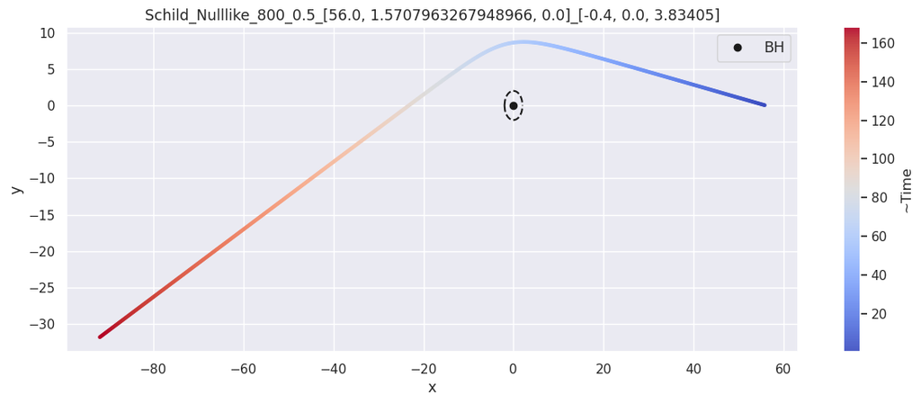

```python
# Definir 4-posición y 4-momentum

q = geod_n3.trajectory[1].T[:4]                  # 4-position (cartesian) [Units of GM/c^2]
p = geod_n3.trajectory[1].T[-4:]                 # 4 momentum (spherical) [dimensionless]

leap = 1
max_ind = steps-10

# name output
metric = 'Schild'       # or Kerr
kind = 'Nulllike'       # or Timelike
name = metric +'_'+ kind +'_'+ str(steps) +'_'+ str(delta) +'_'+ str(position) +'_'+ str(momentum)

plotgeod_q(q, leap, max_ind, name, save=False)
```

**Relativity does work!**

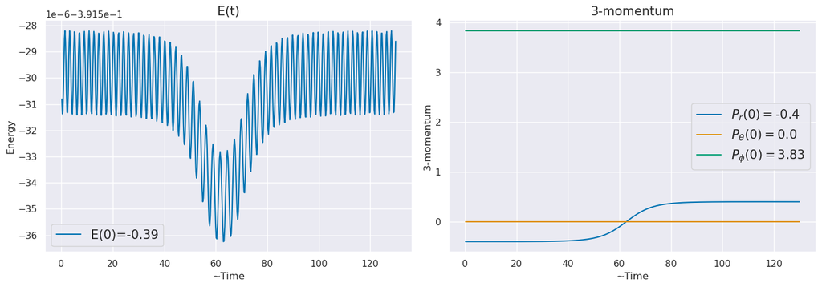

```python
plotgeod_p(q, p, leap, max_ind=600, name=name)
```

```python
p[1][-1]                # P_r final
```

```
np.float64(0.39767470785280296)
```

Se observan pequeñas oscilaciones en la energía y además, luego de ser desviado, el momento $P_r$ del fotón cambió de signo.

Esto se espera, ya que el momento radial inicial comienza siendo negativo, llega al punto de retorno (en este caso al periapsis de su órbita) donde $P_r=0$ y luego escapa al infinito, donde $P_r>0$

[figure not shown]

```python
#r = np.sqrt(q[1]**2+q[2]**2)
#plt.plot(q[0], r)
```